# World Cup Betting Studies: Combined Analysis

Study 1 (Round of 16, 8 matches) and Study 2 (Quarterfinals, 4 matches)

# World Cup Data

## Summary Statistics

### Sample and Demographics

Participant Demographics

| Variable | Study 1 Mean S1 | Study 1 SD S1 | Study 1 Min S1 | Study 1 Median S1 | Study 1 Max S1 | Study 2 Mean S2 | Study 2 SD S2 | Study 2 Min S2 | Study 2 Median S2 | Study 2 Max S2 |
| --- | --- | --- | --- | --- | --- | --- | --- | --- | --- | --- |
| Age | 45.06 | 15.71 | 18 | 46.5 | 88 | 45.14 | 15.50 | 18 | 46 | 83 |
| Education (1-7) | 4.47 | 1.41 | 1 | 5.0 | 7 | 4.39 | 1.41 | 1 | 5 | 7 |
| Financial Wellbeing (1-7) | 4.27 | 1.32 | 1 | 4.0 | 7 | 4.06 | 1.34 | 1 | 4 | 7 |

Gender

| Level | Study 1 n S1 | Study 1 Percent S1 | Study 2 n S2 | Study 2 Percent S2 |
| --- | --- | --- | --- | --- |
| Male | 238 | 47.6 | 244 | 48.8 |
| Female | 256 | 51.2 | 251 | 50.2 |
| Other | 6 | 1.2 | 5 | 1.0 |

Odds Condition Assignment

| Level | Study 1 n S1 | Study 1 Percent S1 | Study 2 n S2 | Study 2 Percent S2 |
| --- | --- | --- | --- | --- |
| No Odds Condition | 263 | 52.6 | 272 | 54.4 |
| American Odds Condition | 237 | 47.4 | 228 | 45.6 |

### Experience Groups

Betting Experience Group

| Level | Study 1 n S1 | Study 1 Percent S1 | Study 2 n S2 | Study 2 Percent S2 |
| --- | --- | --- | --- | --- |
| Low | 189 | 37.8 | 195 | 39 |
| Medium | 155 | 31.0 | 150 | 30 |
| High | 156 | 31.2 | 155 | 31 |

Soccer Experience Group

| Level | Study 1 n S1 | Study 1 Percent S1 | Study 2 n S2 | Study 2 Percent S2 |
| --- | --- | --- | --- | --- |
| Low | 108 | 21.6 | 125 | 25 |
| Medium | 222 | 44.4 | 245 | 49 |
| High | 170 | 34.0 | 130 | 26 |

### Participant-Level Betting Behavior

Betting Behavior (participant level)

| Variable | Study 1 Mean S1 | Study 1 SD S1 | Study 1 Min S1 | Study 1 Median S1 | Study 1 Max S1 | Study 2 Mean S2 | Study 2 SD S2 | Study 2 Min S2 | Study 2 Median S2 | Study 2 Max S2 |
| --- | --- | --- | --- | --- | --- | --- | --- | --- | --- | --- |
| Tokens bet (total) | 93.61 | 17.80 | 0 | 100.00 | 100 | 93.22 | 20.41 | 0 | 100.00 | 100 |
| Tokens kept in bank | 6.39 | 17.80 | 0 | 0.00 | 100 | 6.78 | 20.41 | 0 | 0.00 | 100 |
| Final tokens | 74.00 | 38.30 | 0 | 78.00 | 193 | 88.48 | 46.79 | 0 | 101.00 | 147 |
| Matches with a bet | 6.41 | 2.36 | 0 | 8.00 | 8 | 3.72 | 0.81 | 0 | 4.00 | 4 |
| Mean stated probability | 69.42 | 8.80 | 50 | 68.75 | 100 | 70.02 | 10.19 | 50 | 69.62 | 100 |

### Match-Level Outcomes

Study 1 (Round of 16): Match-Level Summary

| game_id | Team1 | Team2 | % picked T1 (B1) | % bet T1 (B3) | % bet T1 (B4) | Mean tokens | Winner |
| --- | --- | --- | --- | --- | --- | --- | --- |
| 1 | Paraguay | France | 21.2 | 22.8 | 24.2 | 15.6 | France |
| 2 | Canada | Morocco | 28.8 | 34.0 | 35.2 | 8.9 | Morocco |
| 3 | Portugal | Spain | 32.2 | 34.4 | 34.8 | 10.2 | Spain |
| 4 | USA | Belgium | 75.6 | 80.2 | 80.2 | 15.3 | Belgium |
| 5 | Brazil | Norway | 84.0 | 77.2 | 76.8 | 11.4 | Norway |
| 6 | Mexico | England | 44.8 | 44.0 | 44.2 | 10.9 | England |
| 7 | Argentina | Egypt | 91.0 | 84.4 | 83.2 | 12.8 | Argentina |
| 8 | Switzerland | Colombia | 26.8 | 30.8 | 31.4 | 8.5 | Switzerland |

Study 2 (Quarterfinals): Match-Level Summary

| game_id | Team1 | Team2 | % picked T1 (B1) | % bet T1 (B3) | % bet T1 (B4) | Mean tokens | Winner |
| --- | --- | --- | --- | --- | --- | --- | --- |
| 1 | France | Morocco | 74.6 | 70.4 | 69.4 | 23.6 | France |
| 2 | Spain | Belgium | 75.2 | 67.8 | 66.8 | 21.6 | Spain |
| 3 | Norway | England | 39.8 | 46.2 | 48.2 | 24.3 | England |
| 4 | Argentina | Switzerland | 85.4 | 77.2 | 75.4 | 23.7 | Argentina |

### Prediction and Betting Accuracy

Accuracy Overview

| Metric | Study 1 Value S1 | Study 2 Value S2 |
| --- | --- | --- |
| % Block 1 picks correct | 53.90 | 73.85 |
| % Block 4 bets correct | 52.40 | 65.85 |
| % bet matched Block 1 pick | 83.20 | 82.20 |
| Mean Brier score | 0.27 | 0.18 |

## Brier Scores

### Summary Table

Brier Score and Murphy Decomposition

| Study | Method | Component | Estimate | Lower | Upper |
| --- | --- | --- | --- | --- | --- |
| Study 1 | Participants | Brier | 0.27 | 0.27 | 0.28 |
|  |  | Reliability | 0.10 | 0.09 | 0.10 |
|  |  | Resolution | 0.01 | 0.01 | 0.01 |
|  |  | Uncertainty | 0.19 | NA | NA |
|  | Naive 50/50 | Brier | 0.25 | 0.25 | 0.25 |
|  | Always Favorite | Brier | 0.28 | 0.28 | 0.28 |
| Study 2 | Participants | Brier | 0.18 | 0.17 | 0.19 |
|  |  | Reliability | 0.03 | 0.03 | 0.04 |
|  |  | Resolution | 0.03 | 0.03 | 0.04 |
|  |  | Uncertainty | 0.19 | NA | NA |
|  | Naive 50/50 | Brier | 0.25 | 0.25 | 0.25 |
|  | Always Favorite | Brier | 0.00 | 0.00 | 0.00 |

### Graphs

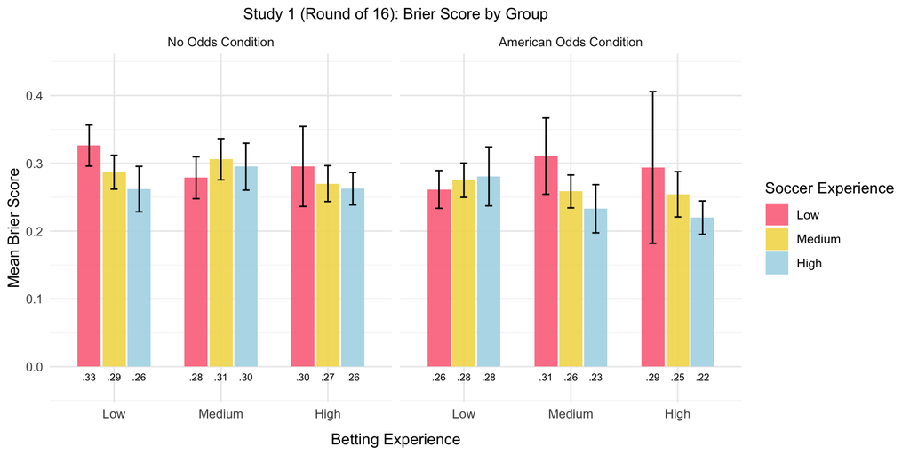

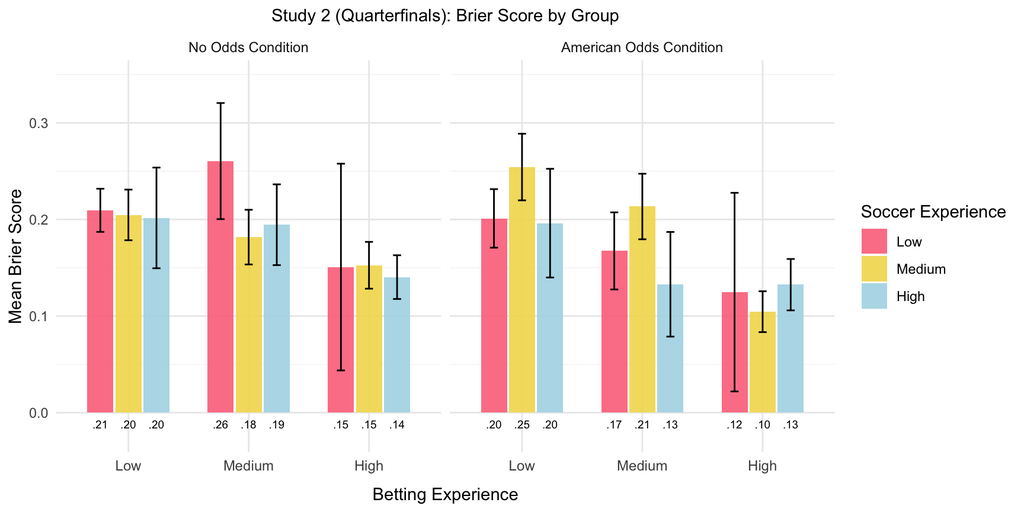

### Regressions

Predicting Brier Score

|  | Study 1 (Round of 16) |  |  | Study 2 (Quarterfinals) |  |  |
| --- | --- | --- | --- | --- | --- | --- |
| Predictors | Estimates | CI | p | Estimates | CI | p |
| (Intercept) | 0.29 | 0.28 – 0.30 | **<0.001** | 0.18 | 0.17 – 0.20 | **<0.001** |
| OddsCondition [American Odds Condition] | -0.03 | -0.05 – -0.01 | **<0.001** | -0.00 | -0.02 – 0.02 | 0.787 |
| BettingExperienceGroup [linear] | -0.01 | -0.03 – 0.00 | 0.067 | -0.05 | -0.07 – -0.03 | **<0.001** |
| BettingExperienceGroup [quadratic] | -0.01 | -0.02 – 0.01 | 0.271 | -0.02 | -0.04 – 0.00 | 0.099 |
| SoccerExperienceGroup [linear] | -0.02 | -0.04 – -0.00 | **0.012** | -0.00 | -0.03 – 0.02 | 0.723 |
| SoccerExperienceGroup [quadratic] | -0.00 | -0.01 – 0.01 | 0.888 | -0.01 | -0.03 – 0.01 | 0.362 |
| Random Effects |  |  |  |  |  |  |
| σ<sup>2</sup> | 0.06 |  |  | 0.03 |  |  |
| τ<sub>00</sub> | 0.00 <sub>ProlificID</sub> |  |  | 0.01 <sub>ProlificID</sub> |  |  |
| ICC | 0.03 |  |  | 0.23 |  |  |
| N | 500 <sub>ProlificID</sub> |  |  | 500 <sub>ProlificID</sub> |  |  |
| Observations | 4000 |  |  | 2000 |  |  |
| Marginal R<sup>2</sup> / Conditional R<sup>2</sup> | 0.008 / 0.039 |  |  | 0.033 / 0.253 |  |  |

Study 1 (Round of 16): Mixed-effects model with random intercept for participant. Study 2 (Quarterfinals): Mixed-effects model with random intercept for participant. Experience groups are ordered factors, so coefficients are polynomial contrasts (`.L` = linear trend across Low/Medium/High, `.Q` = quadratic).

## Consistency of Bets

### Summary Table

Consistency with Higher-EV Team

| Metric | Study 1 | Study 2 |
| --- | --- | --- |
| % consistent (Block 3) | 66.35 | 64.30 |
| % consistent (Block 4) | 66.47 | 64.95 |
| Mean EV gap between teams | 89.33 | 81.62 |

Note: Every match is scored, including those where both teams have negative EV; in those cases betting the less-negative team still counts as consistent.

### Graphs

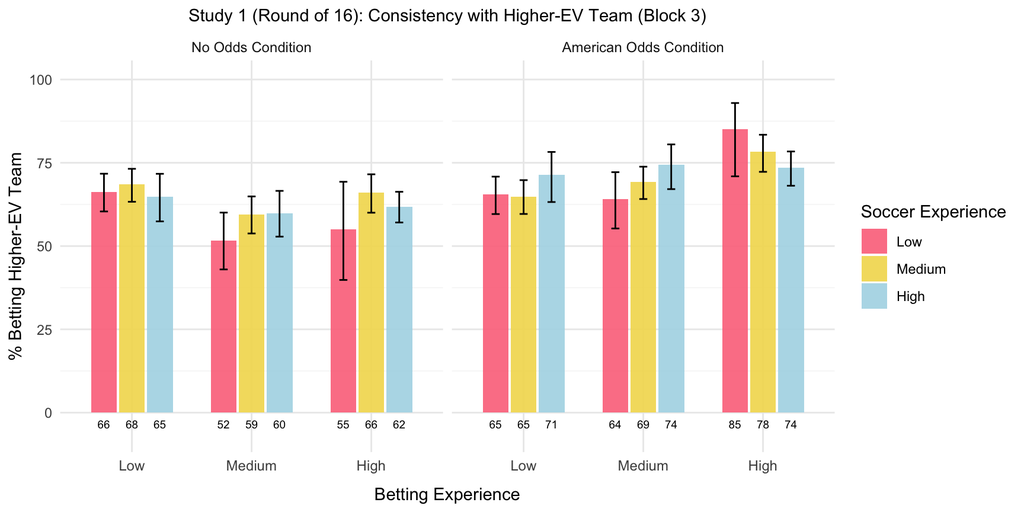

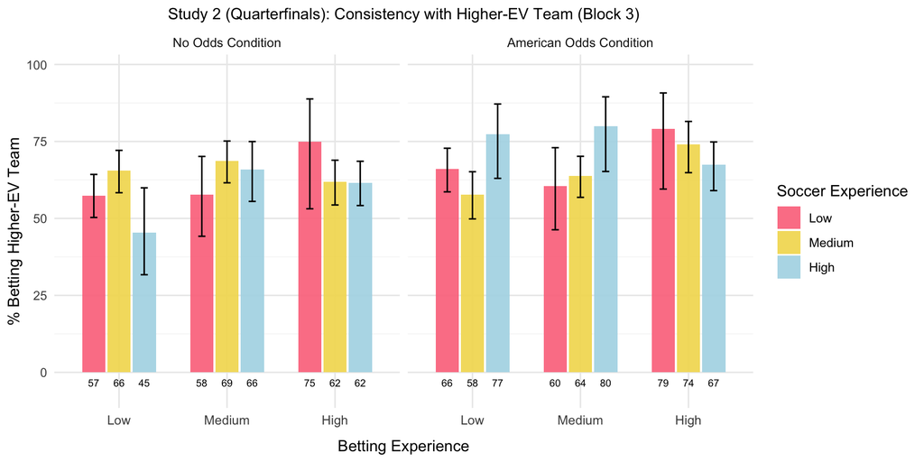

### Regressions

Predicting Consistency with Higher-EV Team (Block 3)

|  | Study 1 (Round of 16) |  |  | Study 2 (Quarterfinals) |  |  |
| --- | --- | --- | --- | --- | --- | --- |
| Predictors | Odds Ratios | CI | p | Odds Ratios | CI | p |
| (Intercept) | 1.77 | 1.55 – 2.02 | **<0.001** | 1.79 | 1.52 – 2.12 | **<0.001** |
| OddsCondition [American Odds Condition] | 1.47 | 1.21 – 1.79 | **<0.001** | 1.23 | 0.97 – 1.56 | 0.092 |
| BettingExperienceGroup [linear] | 1.07 | 0.90 – 1.28 | 0.434 | 1.17 | 0.93 – 1.46 | 0.178 |
| BettingExperienceGroup [quadratic] | 1.18 | 1.00 – 1.40 | 0.052 | 0.94 | 0.76 – 1.16 | 0.548 |
| SoccerExperienceGroup [linear] | 1.09 | 0.89 – 1.33 | 0.414 | 1.03 | 0.79 – 1.33 | 0.853 |
| SoccerExperienceGroup [quadratic] | 0.93 | 0.79 – 1.09 | 0.349 | 0.98 | 0.80 – 1.19 | 0.832 |
| Random Effects |  |  |  |  |  |  |
| σ<sup>2</sup> | 3.29 |  |  | 3.29 |  |  |
| τ<sub>00</sub> | 0.55 <sub>ProlificID</sub> |  |  | 0.58 <sub>ProlificID</sub> |  |  |
| ICC | 0.14 |  |  | 0.15 |  |  |
| N | 500 <sub>ProlificID</sub> |  |  | 500 <sub>ProlificID</sub> |  |  |
| Observations | 4000 |  |  | 2000 |  |  |
| Marginal R<sup>2</sup> / Conditional R<sup>2</sup> | 0.013 / 0.154 |  |  | 0.005 / 0.154 |  |  |

Study 1 (Round of 16): Mixed-effects model with random intercept for participant. Study 2 (Quarterfinals): Mixed-effects model with random intercept for participant.

## Distribution of Bet Amount

### Summary Table

Bet Amount Distribution

| Variable | Study 1 Mean S1 | Study 1 SD S1 | Study 1 Min S1 | Study 1 Median S1 | Study 1 Max S1 | Study 2 Mean S2 | Study 2 SD S2 | Study 2 Min S2 | Study 2 Median S2 | Study 2 Max S2 |
| --- | --- | --- | --- | --- | --- | --- | --- | --- | --- | --- |
| Tokens per match | 11.70 | 13.77 | 0.00 | 10.00 | 100.00 | 23.30 | 15.63 | 0.00 | 25.00 | 100 |
| SD across matches (within person) | 11.42 | 9.00 | 0.00 | 8.44 | 35.36 | 11.66 | 12.46 | 0.00 | 9.57 | 50 |
| Max on a single match | 34.36 | 23.29 | 0.00 | 25.00 | 100.00 | 38.48 | 19.98 | 0.00 | 35.00 | 100 |
| Matches with a bet | 6.41 | 2.36 | 0.00 | 8.00 | 8.00 | 3.72 | 0.81 | 0.00 | 4.00 | 4 |
| Concentration (HHI) | 0.29 | 0.24 | 0.12 | 0.19 | 1.00 | 0.35 | 0.18 | 0.25 | 0.28 | 1 |

Note: HHI (Herfindahl index) ranges from 1/n_matches (perfectly even split) to 1 (all tokens on one match).

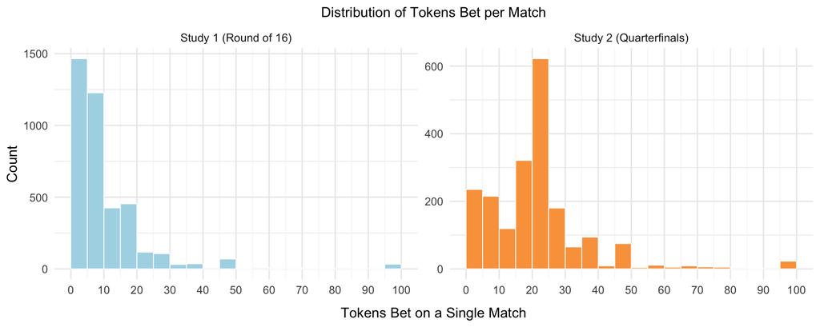

### Graphs

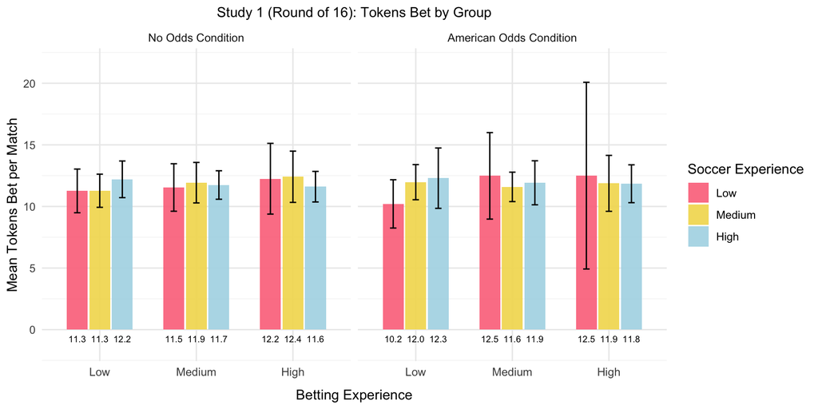

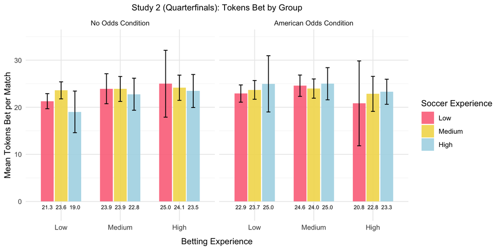

### Regressions

Predicting Allocation Concentration (HHI)

|  | Study 1 (Round of 16) |  |  | Study 2 (Quarterfinals) |  |  |
| --- | --- | --- | --- | --- | --- | --- |
| Predictors | Estimates | CI | p | Estimates | CI | p |
| (Intercept) | 0.28 | 0.26 – 0.31 | **<0.001** | 0.36 | 0.34 – 0.38 | **<0.001** |
| OddsCondition [American Odds Condition] | 0.02 | -0.02 – 0.06 | 0.274 | -0.02 | -0.05 – 0.01 | 0.151 |
| BettingExperienceGroup [linear] | 0.04 | 0.00 – 0.08 | **0.042** | 0.05 | 0.02 – 0.08 | **0.001** |
| BettingExperienceGroup [quadratic] | 0.04 | 0.00 – 0.08 | **0.033** | 0.01 | -0.01 – 0.04 | 0.290 |
| SoccerExperienceGroup [linear] | -0.09 | -0.13 – -0.04 | **<0.001** | 0.04 | 0.01 – 0.07 | **0.022** |
| SoccerExperienceGroup [quadratic] | 0.00 | -0.03 – 0.04 | 0.804 | 0.00 | -0.02 – 0.03 | 0.873 |
| Observations | 495 |  |  | 495 |  |  |
| R<sup>2</sup> / R<sup>2</sup> adjusted | 0.041 / 0.031 |  |  | 0.061 / 0.052 |  |  |

## Participant vs. Sportsbook Probabilities

Whether participants’ stated probabilities departed from the market’s implied probabilities. Positive values mean the participant was **more** confident in their pick than the sportsbook was.

### Summary Table

Stated vs. Sportsbook Probability

| Variable | Study 1 Mean S1 | Study 1 SD S1 | Study 1 Min S1 | Study 1 Median S1 | Study 1 Max S1 | Study 2 Mean S2 | Study 2 SD S2 | Study 2 Min S2 | Study 2 Median S2 | Study 2 Max S2 |
| --- | --- | --- | --- | --- | --- | --- | --- | --- | --- | --- |
| Stated probability (Block 1 pick) | 0.69 | 0.16 | 0.50 | 0.69 | 1.00 | 0.70 | 0.15 | 0.50 | 0.70 | 1.00 |
| Book implied probability (same team) | 0.63 | 0.20 | 0.11 | 0.62 | 0.94 | 0.63 | 0.19 | 0.26 | 0.73 | 0.79 |
| Difference (stated - book) | 0.06 | 0.21 | -0.44 | 0.03 | 0.89 | 0.07 | 0.21 | -0.29 | 0.03 | 0.74 |

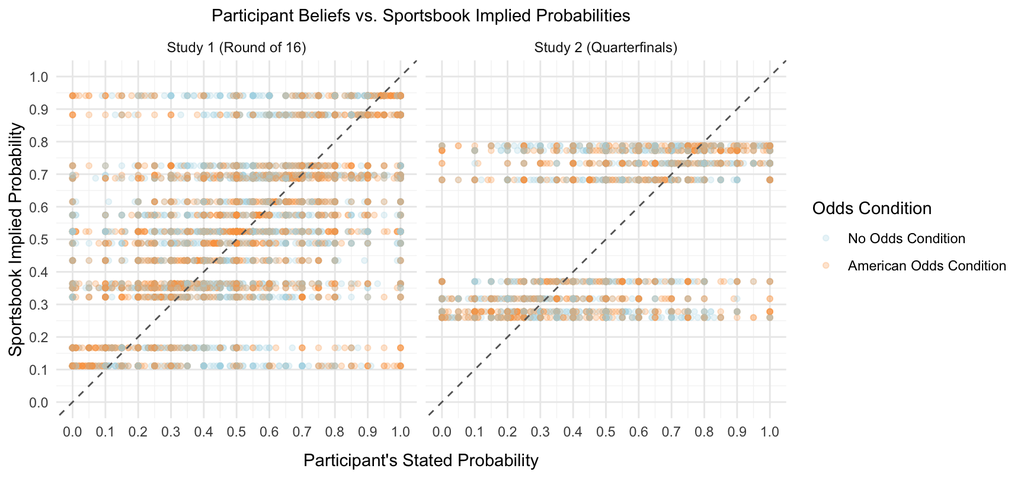

Points on the dashed line indicate perfect agreement with the market. Points below the line mean the participant was more confident than the sportsbook.

### Graphs

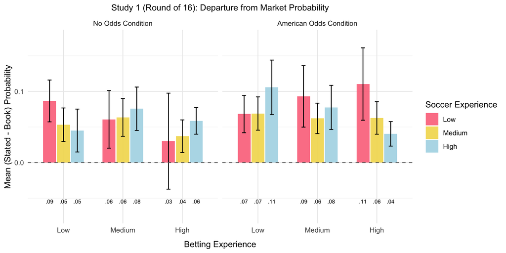

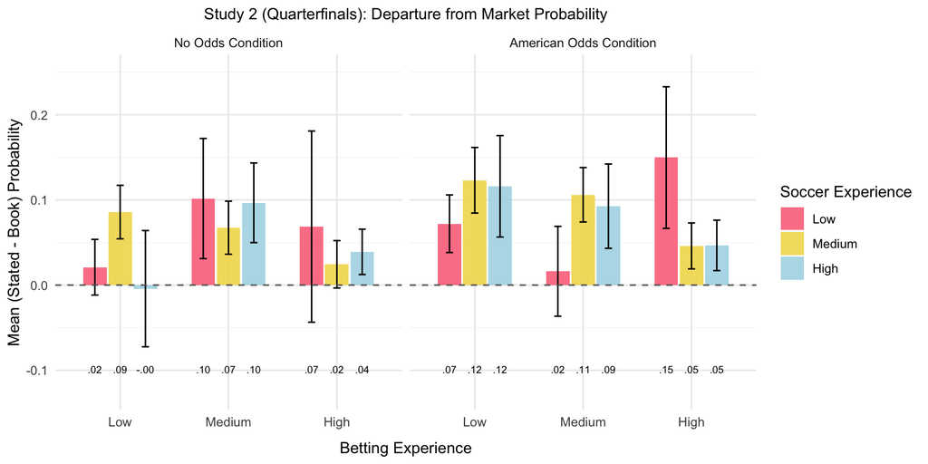

### Regressions

Predicting Departure from Sportsbook Probability

|  | Study 1 (Round of 16) |  |  | Study 2 (Quarterfinals) |  |  |
| --- | --- | --- | --- | --- | --- | --- |
| Predictors | Estimates | CI | p | Estimates | CI | p |
| (Intercept) | 0.06 | 0.05 – 0.08 | **<0.001** | 0.05 | 0.03 – 0.07 | **<0.001** |
| OddsCondition [American Odds Condition] | 0.01 | -0.01 – 0.03 | 0.406 | 0.03 | 0.01 – 0.05 | **0.013** |
| BettingExperienceGroup [linear] | -0.01 | -0.03 – 0.01 | 0.224 | -0.03 | -0.05 – -0.00 | **0.028** |
| BettingExperienceGroup [quadratic] | -0.01 | -0.03 – 0.01 | 0.367 | -0.02 | -0.04 – 0.00 | 0.079 |
| SoccerExperienceGroup [linear] | -0.00 | -0.02 – 0.02 | 0.658 | 0.02 | -0.01 – 0.04 | 0.225 |
| SoccerExperienceGroup [quadratic] | 0.01 | -0.01 – 0.03 | 0.227 | -0.01 | -0.03 – 0.00 | 0.133 |
| Random Effects |  |  |  |  |  |  |
| σ<sup>2</sup> | 0.04 |  |  | 0.03 |  |  |
| τ<sub>00</sub> | 0.01 <sub>ProlificID</sub> |  |  | 0.01 <sub>ProlificID</sub> |  |  |
| ICC | 0.18 |  |  | 0.22 |  |  |
| N | 500 <sub>ProlificID</sub> |  |  | 500 <sub>ProlificID</sub> |  |  |
| Observations | 4000 |  |  | 2000 |  |  |
| Marginal R<sup>2</sup> / Conditional R<sup>2</sup> | 0.003 / 0.183 |  |  | 0.014 / 0.227 |  |  |

Study 1 (Round of 16): Mixed-effects model with random intercept for participant. Study 2 (Quarterfinals): Mixed-effects model with random intercept for participant.

## Betting on the Team Believed to Win

Whether the Block 3 bet matched the team picked to advance in Block 1 — that is, whether people back their own stated belief rather than the market favorite.

### Summary Table

Betting on the Believed Winner

| Metric | Study 1 | Study 2 |
| --- | --- | --- |
| % Block 3 bet matched Block 1 pick | 83.73 | 82.95 |
| % Block 1 pick was the book favorite | 77.65 | 73.85 |
| % Block 4 bet matched Block 1 pick | 83.20 | 82.20 |

### Belief vs. Market: 2x2

Cross-tabulating whether the Block 3 bet matched the Block 1 pick against whether that Block 1 pick agreed with the sportsbook favorite.

Block 1 Pick vs. Block 3 Bet Agreement

| Block 1 Pick | Block 3 Bet | Study 1 | Study 2 |
| --- | --- | --- | --- |
| Picked Book Favorite | Matched Block 1 | 2694 (67.35%) | 1241 (62.05%) |
|  | Switched | 412 (10.3%) | 236 (11.8%) |
| Picked Underdog | Matched Block 1 | 655 (16.38%) | 418 (20.9%) |
|  | Switched | 239 (5.97%) | 105 (5.25%) |

Note: Percentages are of all participant-matches within each study.

% Who Backed Their Block 1 Pick, by Whether It Agreed with the Market

| Block 1 Pick | Study 1 | Study 2 |
| --- | --- | --- |
| Picked Book Favorite | 86.74% | 84.02% |
| Picked Underdog | 73.27% | 79.92% |

### Graphs

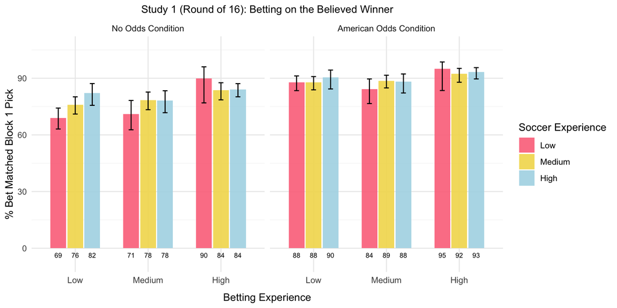

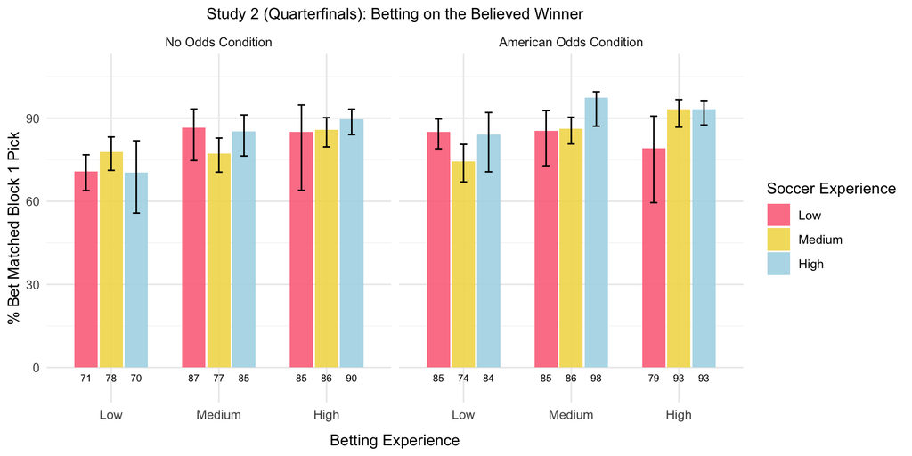

### Regressions

Predicting Betting on the Believed Winner

|  | Study 1 (Round of 16) |  |  | Study 2 (Quarterfinals) |  |  |
| --- | --- | --- | --- | --- | --- | --- |
| Predictors | Odds Ratios | CI | p | Odds Ratios | CI | p |
| (Intercept) | 5.02 | 4.10 – 6.15 | **<0.001** | 9.19 | 6.47 – 13.03 | **<0.001** |
| OddsCondition [American Odds Condition] | 2.91 | 2.15 – 3.93 | **<0.001** | 1.83 | 1.19 – 2.82 | **0.006** |
| BettingExperienceGroup [linear] | 1.46 | 1.11 – 1.93 | **0.006** | 2.36 | 1.55 – 3.58 | **<0.001** |
| BettingExperienceGroup [quadratic] | 1.29 | 1.00 – 1.67 | 0.052 | 0.99 | 0.67 – 1.46 | 0.962 |
| SoccerExperienceGroup [linear] | 1.32 | 0.98 – 1.78 | 0.071 | 1.29 | 0.81 – 2.08 | 0.284 |
| SoccerExperienceGroup [quadratic] | 0.95 | 0.74 – 1.20 | 0.652 | 1.26 | 0.88 – 1.78 | 0.204 |
| Random Effects |  |  |  |  |  |  |
| σ<sup>2</sup> | 3.29 |  |  | 3.29 |  |  |
| τ<sub>00</sub> | 1.35 <sub>ProlificID</sub> |  |  | 2.66 <sub>ProlificID</sub> |  |  |
| ICC | 0.29 |  |  | 0.45 |  |  |
| N | 500 <sub>ProlificID</sub> |  |  | 500 <sub>ProlificID</sub> |  |  |
| Observations | 4000 |  |  | 2000 |  |  |
| Marginal R<sup>2</sup> / Conditional R<sup>2</sup> | 0.073 / 0.343 |  |  | 0.066 / 0.484 |  |  |

# Additional Analyses

Sections below were not part of the required set. They are grouped here for easy review.

## Synthetic Betting Strategies

What would participants have earned if they had allocated tokens purely by the expected values implied by their own Block 1 probabilities? None of these strategies requires knowing the outcome — only the participant’s own beliefs and the posted odds.

- **Equal Split** — 100 tokens divided equally across all positive-EV matches
- **EV Proportional** — 100 tokens split in proportion to each positive-EV match’s EV
- **Max EV Only** — all 100 tokens on the single highest-EV match

Mean Final Tokens: Synthetic Strategies vs. Actual

| Strategy | Study 1 | Study 2 |
| --- | --- | --- |
| Equal Split | 66.43 | 49.44 |
| EV Proportional | 42.02 | 30.32 |
| Max EV Only | 24.87 | 22.12 |
| Actual | 74.00 | 88.48 |

% of Participants for Whom Each Strategy Was Best

| Strategy | Study 1 | Study 2 |
| --- | --- | --- |
| Equal Split | 81.37 | 63.83 |
| EV Proportional | 5.17 | 13.33 |
| Max EV Only | 13.47 | 22.83 |

Note: Ties split credit evenly, so columns sum to 100%.

% of Participants Each Strategy Beat Their Actual Result

| Strategy | Study 1 | Study 2 |
| --- | --- | --- |
| Equal Split | 39.6 | 18.8 |
| EV Proportional | 22.0 | 14.6 |
| Max EV Only | 12.0 | 10.2 |

## Allocation Patterns

Two dimensions describe how tokens were spread: the number of matches receiving a bet, and the concentration of the allocation (HHI). These separate the four intuitive patterns — even across all matches, even across a few, heavy on one with a little elsewhere, and everything on one match.

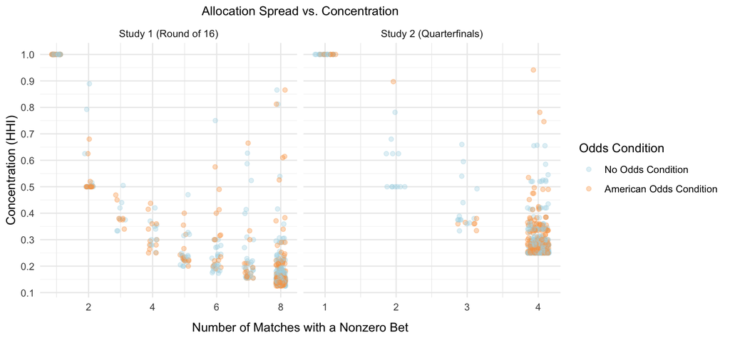

Allocation Pattern Classification

| Pattern | Study 1 | Study 2 |
| --- | --- | --- |
| All on one match | 35 (7%) | 24 (4.8%) |
| Heavily concentrated | 38 (7.6%) | 32 (6.4%) |
| No bets | 5 (1%) | 5 (1%) |
| Spread across a few matches | 101 (20.2%) | NA |
| Spread across most matches | 321 (64.2%) | 439 (87.8%) |

## Expected Value of Bets

Expected Value of Block 4 Bets

| Variable | Study 1 Mean S1 | Study 1 SD S1 | Study 1 Min S1 | Study 1 Median S1 | Study 1 Max S1 | Study 2 Mean S2 | Study 2 SD S2 | Study 2 Min S2 | Study 2 Median S2 | Study 2 Max S2 |
| --- | --- | --- | --- | --- | --- | --- | --- | --- | --- | --- |
| EV of bet (per 100 tokens) | 22.19 | 87.87 | -100.00 | 2.50 | 800.00 | 21.18 | 58.41 | -100.00 | 3.53 | 285.00 |
| EV of bet (tokens actually wagered) | 3.51 | 24.63 | -47.88 | 0.00 | 800.00 | 5.65 | 17.54 | -63.00 | 0.47 | 260.00 |
| Breakeven probability needed | 0.61 | 0.21 | 0.11 | 0.62 | 0.94 | 0.60 | 0.21 | 0.26 | 0.73 | 0.79 |
| Stated prob minus breakeven | 0.03 | 0.22 | -0.94 | 0.02 | 0.89 | 0.05 | 0.22 | -0.68 | 0.03 | 0.74 |

Positive-EV Bet Rate

| Metric | Study 1 | Study 2 |
| --- | --- | --- |
| % of bets with positive EV by own beliefs | 55.88 | 58.2 |

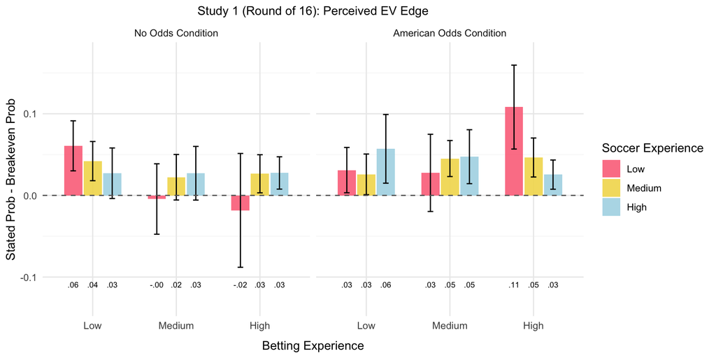

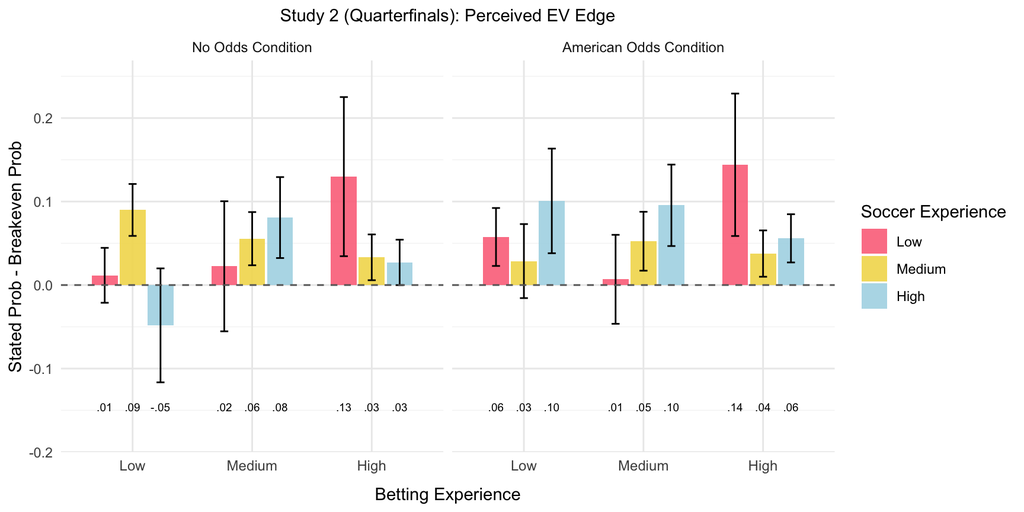

## Team Affinity and Betting

Whether liking a team predicts betting on it, independent of the odds.

Team Affinity and Bet Choice (1 = strong negative, 5 = strong positive)

| Variable | Study 1 Mean S1 | Study 1 SD S1 | Study 1 Min S1 | Study 1 Median S1 | Study 1 Max S1 | Study 2 Mean S2 | Study 2 SD S2 | Study 2 Min S2 | Study 2 Median S2 | Study 2 Max S2 |
| --- | --- | --- | --- | --- | --- | --- | --- | --- | --- | --- |
| Affinity: team bet on | 3.56 | 0.87 | 1 | 4 | 5 | 3.48 | 0.88 | 1 | 3 | 5 |
| Affinity: team not bet on | 3.58 | 0.87 | 1 | 4 | 5 | 3.49 | 0.86 | 1 | 3 | 5 |
| Affinity difference (bet - not bet) | -0.01 | 0.98 | -4 | 0 | 4 | -0.01 | 1.06 | -4 | 0 | 4 |

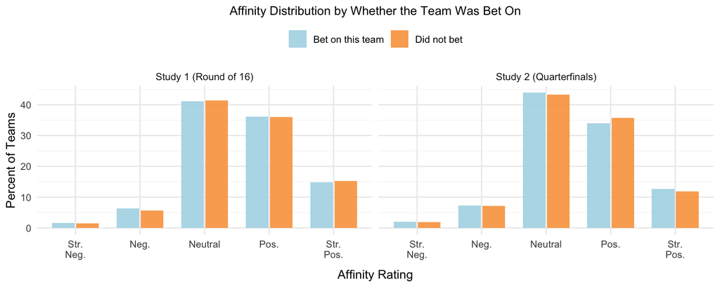

Predicting Betting on the Favorite, Controlling for Affinity

|  | Study 1 (Round of 16) |  |  | Study 2 (Quarterfinals) |  |  |
| --- | --- | --- | --- | --- | --- | --- |
| Predictors | Odds Ratios | CI | p | Odds Ratios | CI | p |
| (Intercept) | 2.97 | 2.44 – 3.61 | **<0.001** | 2.45 | 1.87 – 3.19 | **<0.001** |
| affinity bet diff | 0.96 | 0.88 – 1.05 | 0.379 | 1.11 | 0.99 – 1.25 | 0.080 |
| OddsCondition [American Odds Condition] | 1.91 | 1.44 – 2.53 | **<0.001** | 1.48 | 1.02 – 2.15 | **0.039** |
| BettingExperienceGroup [linear] | 1.68 | 1.30 – 2.17 | **<0.001** | 2.44 | 1.70 – 3.50 | **<0.001** |
| BettingExperienceGroup [quadratic] | 1.16 | 0.91 – 1.49 | 0.230 | 1.09 | 0.78 – 1.52 | 0.606 |
| SoccerExperienceGroup [linear] | 1.07 | 0.80 – 1.43 | 0.640 | 0.92 | 0.61 – 1.39 | 0.695 |
| SoccerExperienceGroup [quadratic] | 1.11 | 0.88 – 1.39 | 0.394 | 1.19 | 0.88 – 1.62 | 0.267 |
| Random Effects |  |  |  |  |  |  |
| σ<sup>2</sup> | 3.29 |  |  | 3.29 |  |  |
| τ<sub>00</sub> | 1.51 <sub>ProlificID</sub> |  |  | 2.53 <sub>ProlificID</sub> |  |  |
| ICC | 0.32 |  |  | 0.44 |  |  |
| N | 500 <sub>ProlificID</sub> |  |  | 500 <sub>ProlificID</sub> |  |  |
| Observations | 4000 |  |  | 2000 |  |  |
| Marginal R<sup>2</sup> / Conditional R<sup>2</sup> | 0.040 / 0.343 |  |  | 0.051 / 0.464 |  |  |

## Relative Influence of Beliefs, EV, and Desirability

### Full Model (do not use)

|  | Study 1 (Round of 16) |  |  | Study 2 (Quarterfinals) |  |  |
| --- | --- | --- | --- | --- | --- | --- |
| Predictors | Odds Ratios | CI | p | Odds Ratios | CI | p |
| (Intercept) | 0.00 | 0.00 – 0.00 | **<0.001** | 0.00 | 0.00 – 0.00 | **<0.001** |
| p fav | 1.12 | 1.11 – 1.14 | **<0.001** | 1.19 | 1.13 – 1.25 | **<0.001** |
| ev fav | 0.62 | 0.47 – 0.82 | **0.001** | 0.19 | 0.04 – 0.91 | **0.038** |
| ev dog | 1.25 | 1.08 – 1.45 | **0.003** | 0.77 | 0.33 – 1.82 | 0.555 |
| desirability fav | 1.02 | 0.91 – 1.14 | 0.709 | 1.06 | 0.89 – 1.26 | 0.507 |
| desirability dog | 1.07 | 0.96 – 1.20 | 0.229 | 1.04 | 0.88 – 1.24 | 0.637 |
| Random Effects |  |  |  |  |  |  |
| σ<sup>2</sup> | 3.29 |  |  | 3.29 |  |  |
| τ<sub>00</sub> | 2.23 <sub>ProlificID</sub> |  |  | 4.33 <sub>ProlificID</sub> |  |  |
| ICC | 0.40 |  |  | 0.57 |  |  |
| N | 500 <sub>ProlificID</sub> |  |  | 500 <sub>ProlificID</sub> |  |  |
| Observations | 4000 |  |  | 2000 |  |  |
| Marginal R<sup>2</sup> / Conditional R<sup>2</sup> | 0.457 / 0.677 |  |  | 0.399 / 0.740 |  |  |

### p(fav) Omitted

|  | Study 1 (Round of 16) |  |  | Study 2 (Quarterfinals) |  |  |
| --- | --- | --- | --- | --- | --- | --- |
| Predictors | Odds Ratios | CI | p | Odds Ratios | CI | p |
| (Intercept) | 2.25 | 1.97 – 2.57 | **<0.001** | 3.79 | 2.94 – 4.89 | **<0.001** |
| ev fav | 6.69 | 5.61 – 7.97 | **<0.001** | 23.08 | 10.22 – 52.14 | **<0.001** |
| ev dog | 1.90 | 1.68 – 2.15 | **<0.001** | 2.95 | 1.38 – 6.31 | **0.005** |
| desirability fav | 1.01 | 0.92 – 1.12 | 0.791 | 1.04 | 0.88 – 1.23 | 0.634 |
| desirability dog | 1.08 | 0.98 – 1.19 | 0.110 | 1.06 | 0.90 – 1.25 | 0.500 |
| Random Effects |  |  |  |  |  |  |
| σ<sup>2</sup> | 3.29 |  |  | 3.29 |  |  |
| τ<sub>00</sub> | 1.34 <sub>ProlificID</sub> |  |  | 3.79 <sub>ProlificID</sub> |  |  |
| ICC | 0.29 |  |  | 0.54 |  |  |
| N | 500 <sub>ProlificID</sub> |  |  | 500 <sub>ProlificID</sub> |  |  |
| Observations | 4000 |  |  | 2000 |  |  |
| Marginal R<sup>2</sup> / Conditional R<sup>2</sup> | 0.330 / 0.524 |  |  | 0.383 / 0.713 |  |  |

### Both EV Terms Omitted

|  | Study 1 (Round of 16) |  |  | Study 2 (Quarterfinals) |  |  |
| --- | --- | --- | --- | --- | --- | --- |
| Predictors | Odds Ratios | CI | p | Odds Ratios | CI | p |
| (Intercept) | 0.01 | 0.01 – 0.02 | **<0.001** | 0.01 | 0.00 – 0.01 | **<0.001** |
| p fav | 1.10 | 1.09 – 1.10 | **<0.001** | 1.11 | 1.10 – 1.12 | **<0.001** |
| desirability fav | 1.02 | 0.92 – 1.14 | 0.664 | 1.05 | 0.89 – 1.25 | 0.556 |
| desirability dog | 1.08 | 0.97 – 1.20 | 0.178 | 1.05 | 0.88 – 1.24 | 0.601 |
| Random Effects |  |  |  |  |  |  |
| σ<sup>2</sup> | 3.29 |  |  | 3.29 |  |  |
| τ<sub>00</sub> | 2.10 <sub>ProlificID</sub> |  |  | 4.21 <sub>ProlificID</sub> |  |  |
| ICC | 0.39 |  |  | 0.56 |  |  |
| N | 500 <sub>ProlificID</sub> |  |  | 500 <sub>ProlificID</sub> |  |  |
| Observations | 4000 |  |  | 2000 |  |  |
| Marginal R<sup>2</sup> / Conditional R<sup>2</sup> | 0.449 / 0.663 |  |  | 0.397 / 0.735 |  |  |

Collinearity Check

| Metric | Study 1 | Study 2 |
| --- | --- | --- |
| Correlation: EV(favorite) and EV(underdog) | -0.72 | -0.98 |
| Correlation: p(favorite) and EV(favorite) | 0.86 | 0.99 |